# FigureYa33DCA_update

# Academic Citation

If you use this code in your work or research, we kindly request that you cite our publication:

Xiaofan Lu, et al. (2025). FigureYa: A Standardized Visualization Framework for Enhancing Biomedical Data Interpretation and Research Efficiency. iMetaMed. https://doi.org/10.1002/imm3.70005

## 需求描述

## Requirement description

画出paper里的DCA曲线

Draw the DCA curve from the paper

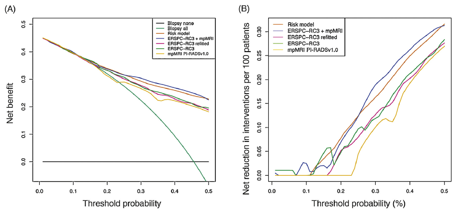

出自https://www.europeanurology.com/article/S0302-2838(17)30267-1/fulltext

fromhttps://www.europeanurology.com/article/S0302-2838(17)30267-1/fulltext

# 应用场景

# Application scenario

生存数据因为带了时间和事件发生的混合因素，适合用`stdca.R`这个function，是MSKCC的统计学专家写的。

队列研究里，像例文的B图那样，有opt-in 和opt-out两种选择，来帮助确定高风险的患者进行干预、低风险的患者避免过度医疗。这个图的最终目的就是为了展示这个价值。

Survival data, which involves the combination of time and event occurrence factors, is suitable for using the `stdca.R` function, written by statistical experts at MSKCC.

In cohort studies, like the B-figure in the example, there are both opt-in and opt-out choices to help identify high-risk patients for intervention and low-risk patients to avoid overmedication. The ultimate purpose of this graph is to demonstrate this value.

# 环境设置

# Environment setting

use the domestic mirror installation package

```r
source("install_dependencies.R")
```

```
## Starting R package installation...
## ===========================================
##
## Installing CRAN packages...
## Package already installed: cmprsk
## Package already installed: cowplot
## Package already installed: ggplotify
## Package already installed: magick
## Package already installed: survival
##
## ===========================================
## Package installation completed!
## You can now run your R scripts in this directory.
```

```r
install.packages("magick")
install.packages("cmprsk")
```

load package

```r
library(survival)
library(ggplotify)
library(magick)
library(cowplot)

Sys.setenv(LANGUAGE = "en") #显示英文报错信息 display English error messages
options(stringsAsFactors = FALSE) #禁止chr转成factor prohibit the conversion of chr to factor
```

加载自定义函数

`stdca.R`文件里的画图函数来自：https://github.com/matt-black/dcapy/blob/master/test/resource/stdca.R

关于该函数的用法，查看本压缩包中的`R stdca Help File.pdf`

为了画出更美观的图，修改了`stdca.R`文件的图例位置、线型和线的颜色

在修改的代码前后用`#Ya#汉字`的形式标记，搜索’#Ya#’就能找到修改的地方。

Load custom functions

The drawing function in the `stdca.R` file is from: https://github.com/matt-black/dcapy/blob/master/test/resource/stdca.R

For the usage of this function, see `R stdca Help File.pdf` in this zip file.

Changed the legend position, line type, and line color in the `stdca.R` file for a better looking diagram.

Use `#Ya#Chinese character` to mark the modified code before and after the modifications, search for ‘#Ya#’ to find the modifications.

```r
source("stdca.R") #stdca.R文件位于当前文件夹 stdca.R file is located in the current folder
```

# 输入文件

# Input file

easy_input.txt，跟`FigureYa30nomogram`里的easy_input.txt是同一个文件，来自`survival`包。

easy_input.txt, the same file as easy_input.txt in `FigureYa30nomogram`, from the `survival` package.

```r
pbc <- read.table("easy_input.txt")
pbc <- pbc[complete.cases(pbc),] #删掉缺失数据 delete missing data
#先把bili分为三类：低、中、高
#first, categorize bili into three groups: low, medium, and high
pbc$catbili <- cut(pbc$bili,breaks=c(-Inf, 2, 4, Inf),
                   labels=c("low","medium","high"))

#把status分为两类，原来的2为变成1，原来的1和0变成0
#split status into two categories, the original 2 to become 1, the original 1 and 0 to become 0
pbc$died <- pbc$status==2
pbc$status <- ifelse(pbc$died=="TRUE",1,0)

head(pbc)
```

```
##          time status trt      age sex ascites hepato spiders edema bili chol
## patient1  400      1   1 58.76523   f       1      1       1   1.0 14.5  261
## patient2 4500      0   1 56.44627   f       0      1       1   0.0  1.1  302
## patient3 1012      1   1 70.07255   m       0      0       0   0.5  1.4  176
## patient4 1925      1   1 54.74059   f       0      1       1   0.5  1.8  244
## patient5 1504      0   2 38.10541   f       0      1       1   0.0  3.4  279
## patient7 1832      0   2 55.53457   f       0      1       0   0.0  1.0  322
##          albumin copper alk.phos    ast trig platelet protime stage catbili
## patient1    2.60    156   1718.0 137.95  172      190    12.2     4    high
## patient2    4.14     54   7394.8 113.52   88      221    10.6     3     low
## patient3    3.48    210    516.0  96.10   55      151    12.0     4     low
## patient4    2.54     64   6121.8  60.63   92      183    10.3     4     low
## patient5    3.53    143    671.0 113.15   72      136    10.9     3  medium
## patient7    4.09     52    824.0  60.45  213      204     9.7     3     low
##           died
## patient1  TRUE
## patient2 FALSE
## patient3  TRUE
## patient4  TRUE
## patient5 FALSE
## patient7 FALSE
```

模仿`easy_input.txt`，修改你手里数据的格式。

Mimic `easy_input.txt` and modify the format of the data you have in hand.

### 利用系数重新预测模型

### Repredict the model using the coefficients

```r
Srv = Surv(pbc$time, pbc$died)

#此处选择5年的时间节点，输入文件的time列的单位是天，5年是1825天。
#下面每两行计算1种cox模型的系数，后面将画图对比
#这里模型的名字写为model1、model2，相应的图中也会显示这个名字。
#实际使用时，修改为你最终要呈现到图中的名字
#Here choose a 5 year timestep, the time column of the input file is in days, 5 years is 1825 days.
#Below, every two lines calculate the coefficients of one type of Cox model, followed by a comparison through plotting.
#Here the name of the model is written as model1, model2, and the corresponding graph will show this name.
#When you use them in practice, change them to the names you want to show in the graph.
coxmod1 = coxph(Srv ~ trt + age + sex + hepato + catbili + copper + stage, data=pbc)
pbc$model1 = c(1 - (summary(survfit(coxmod1, newdata=pbc), times=1825)$surv))

coxmod2 = coxph(Srv ~ ascites + spiders + edema + chol + albumin + alk.phos + ast + trig + platelet + protime, data=pbc)
pbc$model2 = c(1 - (summary(survfit(coxmod2,newdata=pbc), times=1825)$surv))

coxmod3 = coxph(Srv ~ trt + age + sex + hepato + catbili + copper + stage + ascites + spiders + edema + chol + albumin + alk.phos + ast + trig + platelet + protime, data=pbc)
pbc$model3 = c(1 - (summary(survfit(coxmod3,newdata=pbc), times=1825)$surv))

coxmod4 = coxph(Srv ~ stage, data=pbc)
pbc$model4 = c(1 - (summary(survfit(coxmod4,newdata=pbc), times=1825)$surv))

head(pbc)
```

```
##          time status trt      age sex ascites hepato spiders edema bili chol
## patient1  400      1   1 58.76523   f       1      1       1   1.0 14.5  261
## patient2 4500      0   1 56.44627   f       0      1       1   0.0  1.1  302
## patient3 1012      1   1 70.07255   m       0      0       0   0.5  1.4  176
## patient4 1925      1   1 54.74059   f       0      1       1   0.5  1.8  244
## patient5 1504      0   2 38.10541   f       0      1       1   0.0  3.4  279
## patient7 1832      0   2 55.53457   f       0      1       0   0.0  1.0  322
##          albumin copper alk.phos    ast trig platelet protime stage catbili
## patient1    2.60    156   1718.0 137.95  172      190    12.2     4    high
## patient2    4.14     54   7394.8 113.52   88      221    10.6     3     low
## patient3    3.48    210    516.0  96.10   55      151    12.0     4     low
## patient4    2.54     64   6121.8  60.63   92      183    10.3     4     low
## patient5    3.53    143    671.0 113.15   72      136    10.9     3  medium
## patient7    4.09     52    824.0  60.45  213      204     9.7     3     low
##           died    model1     model2     model3    model4
## patient1  TRUE 0.8486997 0.99978389 0.99988527 0.4815053
## patient2 FALSE 0.1353798 0.18181600 0.07910317 0.2548119
## patient3  TRUE 0.3059580 0.33324595 0.60998186 0.4815053
## patient4  TRUE 0.2069089 0.62138644 0.31896476 0.4815053
## patient5 FALSE 0.3910711 0.26400789 0.22497921 0.2548119
## patient7 FALSE 0.1375828 0.06117112 0.04228203 0.2548119
```

# 开始画图

# Start drawing

## 画Net benefit

## Draw Net benefit

画一条

Draw one

```r
mod1 <- stdca(data=pbc, outcome="status", ttoutcome="time", timepoint=1825,
                 predictors="model1", # 跟上一步模型的名字一致 same name as the model in the previous step
              cmprsk=TRUE, smooth=TRUE, xstop=0.5,intervention="FALSE")
```

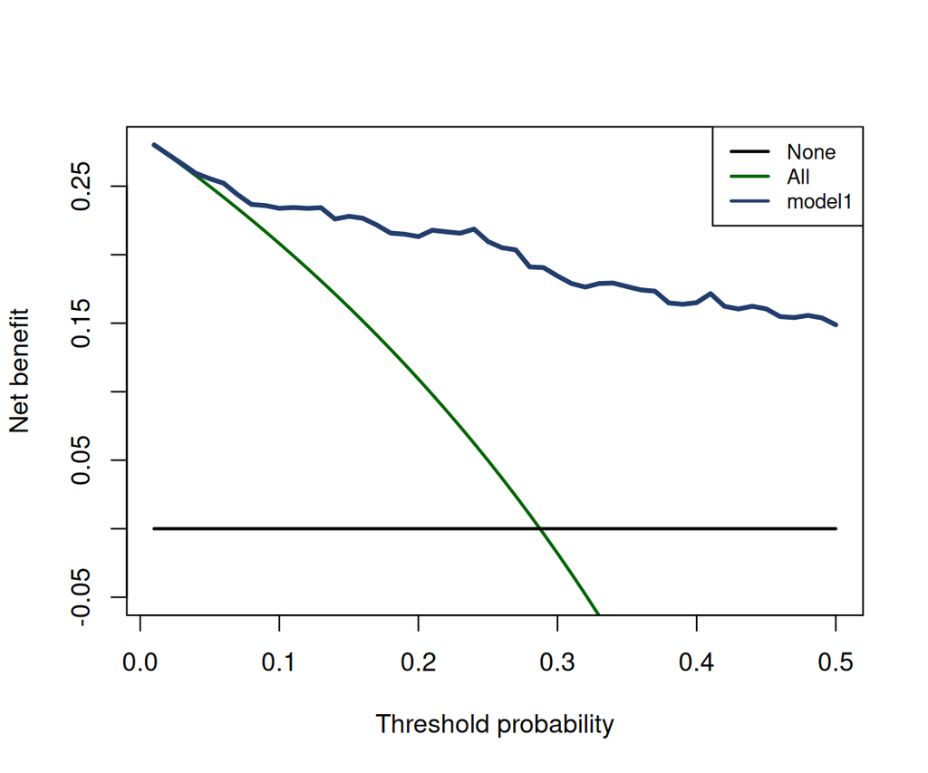

```r
#mod2 <- stdca(data=pbc, outcome="status", ttoutcome="time", timepoint=1825,
#             predictors="model2", cmprsk=TRUE, smooth=TRUE, xstop=0.5,intervention="FALSE")

#mod3 <- stdca(data=pbc, outcome="status", ttoutcome="time", timepoint=1825,
#             predictors="model3", cmprsk=TRUE, smooth=TRUE, xstop=0.5,intervention="FALSE")

#mod4 <- stdca(data=pbc, outcome="status", ttoutcome="time", timepoint=1825,
#             predictors="model4", cmprsk=TRUE, smooth=TRUE, xstop=0.5,intervention="FALSE")
```

多条对比

Multiple comparisons

```r
pdf("net_benefit.pdf",width = 6,height = 6)
stdca(data=pbc, outcome="status", ttoutcome="time", timepoint=1825,
      predictors=c("model1","model2","model3","model4"), # 跟前面模型的名字保持一致 consistent with the name of the previous model
      cmprsk=TRUE, smooth=TRUE,
      xstop=0.5,intervention="FALSE")
```

```
## [1] "model4: No observations with risk greater than 49%, and therefore net benefit not calculable in this range."
```

```
## $N
## [1] 276
##
## $predictors
##   predictor harm.applied probability
## 1    model1            0        TRUE
## 2    model2            0        TRUE
## 3    model3            0        TRUE
## 4    model4            0        TRUE
##
## $interventions.avoided.per
## [1] 100
##
## $net.benefit
##    threshold          all none    model1     model2    model3      model4
```

[output cut: 205 more lines]

```r
dev.off()
```

[figure not shown]

## 画干预的net reduction

## Draw intervention for net reduction

画一条

Draw one

```r
mod1 <- stdca(data=pbc, outcome="status", ttoutcome="time", timepoint=1825,
      predictors="model1", cmprsk=TRUE, smooth=TRUE, xstop=0.5,intervention="TRUE")
```

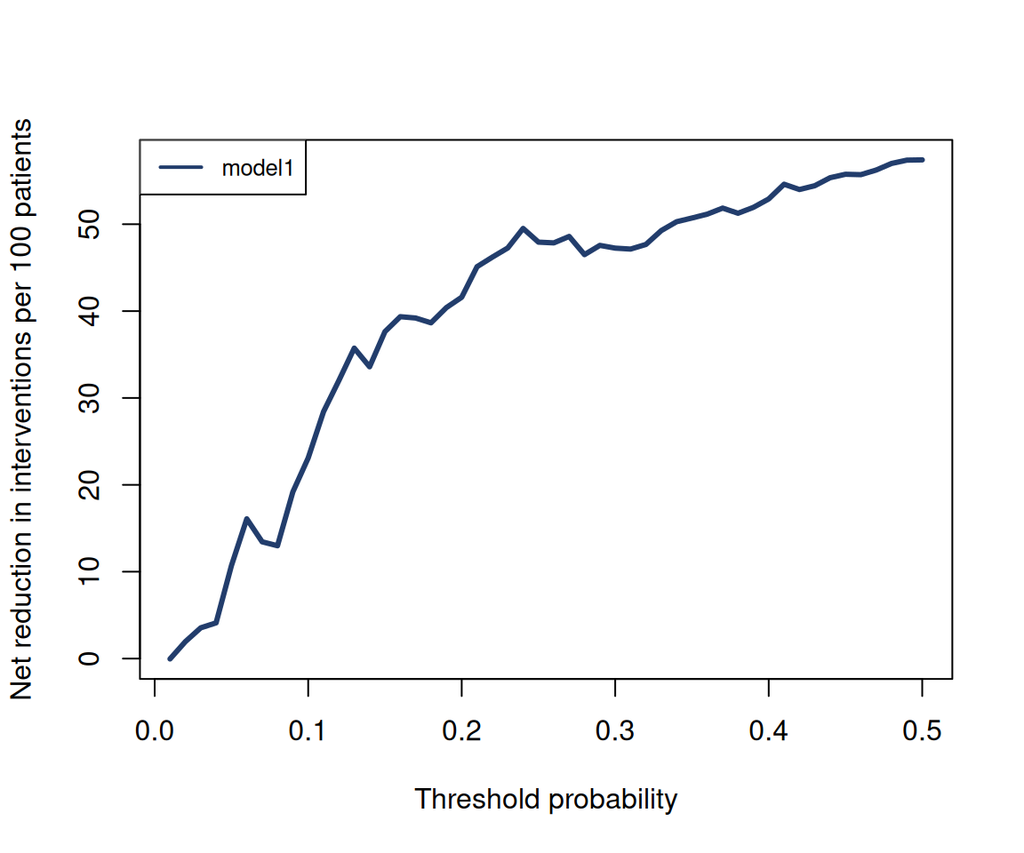

```r
#mod2 <- stdca(data=pbc, outcome="status", ttoutcome="time", timepoint=1825,
#      predictors="model2", cmprsk=TRUE, smooth=TRUE, xstop=0.5,intervention="TRUE")

#mod3 <- stdca(data=pbc, outcome="status", ttoutcome="time", timepoint=1825,
#      predictors="model3", cmprsk=TRUE, smooth=TRUE, xstop=0.5,intervention="TRUE")

#mod4 <- stdca(data=pbc, outcome="status", ttoutcome="time", timepoint=1825,
#      predictors="model4", cmprsk=TRUE, smooth=TRUE, xstop=0.5,intervention="TRUE")
```

多条对比

Multiple comparisons

```r
pdf("net_reduction.pdf",width = 6,height = 6)
stdca(data=pbc, outcome="status", ttoutcome="time", timepoint=1825,
      predictors=c("model1","model2","model3","model4"),
      cmprsk=TRUE, smooth=TRUE,
      xstop=0.5,intervention="TRUE")
```

```
## [1] "model4: No observations with risk greater than 49%, and therefore net benefit not calculable in this range."
```

```
## $N
## [1] 276
##
## $predictors
##   predictor harm.applied probability
## 1    model1            0        TRUE
## 2    model2            0        TRUE
## 3    model3            0        TRUE
## 4    model4            0        TRUE
##
## $interventions.avoided.per
## [1] 100
##
## $net.benefit
##    threshold          all none    model1     model2    model3      model4
```

[output cut: 205 more lines]

```r
dev.off()
```

[figure not shown]

# 其他参考资料

# Other references

DCA很年轻，资料不多，这里提供两个资料，供参考：

优缺点看这篇：http://jama.jamanetwork.com/article.aspx?articleID=2091968

这里还有教程、R和Stata代码：https://www.mskcc.org/sites/default/files/node/4509/documents/dca-tutorial-2015-2-26.pdf

DCA is very young and not much information is available, so here are two sources for reference:

See this one for advantages and disadvantages: http://jama.jamanetwork.com/article.aspx?articleID=2091968

There are also tutorials, R and Stata codes here: https://www.mskcc.org/sites/default/files/node/4509/documents/dca-tutorial-2015-2-26.pdf